# HR Analytics: Model Predykcji Awansów

dr Sebastian Wójcik (Prowadzący)

15-06-2025

## Wyższa Szkoła Informatyki i Zarządzania z siedzibą w Rzeszowie

| **Imię i Nazwisko:** | Pavlo Mysiuk | Roman Bezshchasnyi | Vladyslav Korniichuk |
| --- | --- | --- | --- |
| **Numer albumu:** | W70474 | W69930 | W69943 |
| **Nazwa przedmiotu:** | Drążenie danych |  |  |
| **Rok akademicki:** | 2024/2025 |  |  |

# Wprowadzenie

Celem niniejszej analizy jest zbudowanie i ocena modeli uczenia maszynowego służących do predykcji, którzy pracownicy powinni zostać zakwalifikowani do awansu. W ramach projektu przetestowane zostaną trzy różne algorytmy klasyfikacyjne. Ich skuteczność zostanie oceniona przy użyciu walidacji krzyżowej oraz metryk pochodzących z macierzy pomyłek, takich jak: **dokładność (Accuracy)**, **precyzja (Precision)**, **czułość (Recall)** oraz **F1-Score**.

# 1. Przygotowanie Danych

Pierwszym krokiem jest załadowanie danych z pliku `train.csv`, a następnie ich oczyszczenie i przygotowanie do procesu modelowania.

```r
df <- read_delim("train.csv", delim = ";")

# Konwersja zmiennych na typ 'factor'
df <- df %>%
  mutate(
    is_promoted = factor(is_promoted, levels = c(0, 1), labels = c("Nie", "Tak")),
    gender = as.factor(gender),
    department = as.factor(department),
    region = as.factor(region),
    recruitment_channel = as.factor(recruitment_channel)
  )

# Uzupełnienie brakujących wartości (NA)
df$previous_year_rating[is.na(df$previous_year_rating)] <- median(df$previous_year_rating, na.rm = TRUE)
mode_education <- names(sort(table(df$education), decreasing = TRUE))[1]
df$education[is.na(df$education)] <- mode_education
df$education <- as.factor(df$education)

# Usunięcie zbędnej kolumny
df <- df %>% select(-employee_id)

# Podział na zbiór treningowy (75%) i testowy (25%)
set.seed(123)
train_index <- createDataPartition(df$is_promoted, p = 0.75, list = FALSE)
train_data <- df[train_index, ]
test_data <- df[-train_index, ]
```

Przegląd pierwszych wierszy załadowanego zbioru danych:

Pierwsze 6 wierszy zbioru danych

| department | region | education | gender | recruitment_channel | no_of_trainings | age | previous_year_rating | length_of_service | KPI | awards_won | avg_training_score | is_promoted |
| --- | --- | --- | --- | --- | --- | --- | --- | --- | --- | --- | --- | --- |
| Sales & Marketing | region_7 | Master’s & above | f | sourcing | 1 | 35 | 5 | 8 | Yes | No | 49 | Nie |
| Operations | region_22 | Bachelor’s | m | other | 1 | 30 | 5 | 4 | No | No | 60 | Nie |
| Sales & Marketing | region_19 | Bachelor’s | m | sourcing | 1 | 34 | 3 | 7 | No | No | 50 | Nie |
| Sales & Marketing | region_23 | Bachelor’s | m | other | 2 | 39 | 1 | 10 | No | No | 50 | Nie |
| Technology | region_26 | Bachelor’s | m | other | 1 | 45 | 3 | 2 | No | No | 73 | Nie |
| Analytics | region_2 | Bachelor’s | m | sourcing | 2 | 31 | 3 | 7 | No | No | 85 | Nie |

# 2. Budowa i Ocena Modeli Klasyfikacyjnych

Do trenowania modeli zostanie wykorzystana **5-krotna walidacja krzyżowa**, co zapewni większą stabilność i wiarygodność wyników.

## Model 1: Regresja Logistyczna (GLM)

Regresja logistyczna to podstawowy i szybki model, stanowiący dobry punkt odniesienia dla bardziej złożonych algorytmów.

```r
model_glm <- train(
  is_promoted ~ .,
  data = train_data,
  method = "glm",
  family = "binomial",
  trControl = train_control
)

pred_glm <- predict(model_glm, test_data)
cm_glm <- confusionMatrix(pred_glm, test_data$is_promoted, positive = "Tak")

print(cm_glm)
```

```
## Confusion Matrix and Statistics
##
##           Reference
## Prediction   Nie   Tak
##        Nie 12444   870
##        Tak    91   297
##
##                Accuracy : 0.9299
##                  95% CI : (0.9255, 0.9341)
##     No Information Rate : 0.9148
##     P-Value [Acc > NIR] : 5.018e-11
##
##                   Kappa : 0.3546
##
##  Mcnemar's Test P-Value : < 2.2e-16
##
##             Sensitivity : 0.25450
##             Specificity : 0.99274
##          Pos Pred Value : 0.76546
##          Neg Pred Value : 0.93466
##              Prevalence : 0.08517
##          Detection Rate : 0.02168
##    Detection Prevalence : 0.02832
##       Balanced Accuracy : 0.62362
##
##        'Positive' Class : Tak
##
```

## Model 2: Drzewo Decyzyjne (rpart)

Drzewa decyzyjne są modelem łatwym do interpretacji graficznej, co pozwala na zrozumienie logiki podejmowania decyzji.

```r
model_rpart <- train(
  is_promoted ~ .,
  data = train_data,
  method = "rpart",
  trControl = train_control,
  tuneLength = 5
)

pred_rpart <- predict(model_rpart, test_data)
cm_rpart <- confusionMatrix(pred_rpart, test_data$is_promoted, positive = "Tak")

print(cm_rpart)
```

```
## Confusion Matrix and Statistics
##
##           Reference
## Prediction   Nie   Tak
##        Nie 12463   881
##        Tak    72   286
##
##                Accuracy : 0.9304
##                  95% CI : (0.9261, 0.9347)
##     No Information Rate : 0.9148
##     P-Value [Acc > NIR] : 8.702e-12
##
##                   Kappa : 0.3491
##
##  Mcnemar's Test P-Value : < 2.2e-16
##
##             Sensitivity : 0.24507
##             Specificity : 0.99426
##          Pos Pred Value : 0.79888
##          Neg Pred Value : 0.93398
##              Prevalence : 0.08517
##          Detection Rate : 0.02087
##    Detection Prevalence : 0.02613
##       Balanced Accuracy : 0.61966
##
##        'Positive' Class : Tak
##
```

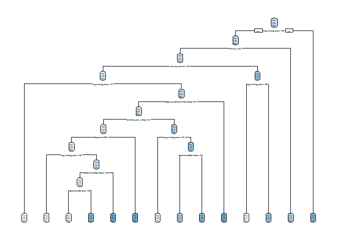

Wizualizacja drzewa decyzyjnego

```r
rpart.plot(model_rpart$finalModel, box.palette = "Blues", roundint = FALSE)
```

## Model 3: Las Losowy (Random Forest)

Las losowy to zaawansowany model zespołowy (ensemble), który buduje wiele drzew decyzyjnych, co zazwyczaj prowadzi do uzyskania wyższej skuteczności predykcyjnej.

```r
model_rf <- train(
  is_promoted ~ .,
  data = train_data,
  method = "rf",
  trControl = train_control,
  tuneGrid = expand.grid(.mtry = c(2, 5, 10))
)

pred_rf <- predict(model_rf, test_data)
cm_rf <- confusionMatrix(pred_rf, test_data$is_promoted, positive = "Tak")

print(cm_rf)
```

```
## Confusion Matrix and Statistics
##
##           Reference
## Prediction   Nie   Tak
##        Nie 12507   822
##        Tak    28   345
##
##                Accuracy : 0.938
##                  95% CI : (0.9338, 0.9419)
##     No Information Rate : 0.9148
##     P-Value [Acc > NIR] : < 2.2e-16
##
##                   Kappa : 0.4243
##
##  Mcnemar's Test P-Value : < 2.2e-16
##
##             Sensitivity : 0.29563
##             Specificity : 0.99777
##          Pos Pred Value : 0.92493
##          Neg Pred Value : 0.93833
##              Prevalence : 0.08517
##          Detection Rate : 0.02518
##    Detection Prevalence : 0.02722
##       Balanced Accuracy : 0.64670
##
##        'Positive' Class : Tak
##
```

# 3. Porównanie Modeli i Wnioski

Ostateczne porównanie skuteczności wszystkich modeli na **zbiorze testowym** zostało przedstawione w tabeli poniżej.

```r
results_summary <- data.frame(
  Model = c("Regresja Logistyczna", "Drzewo Decyzyjne", "Las Losowy"),
  Accuracy = c(cm_glm$overall['Accuracy'], cm_rpart$overall['Accuracy'], cm_rf$overall['Accuracy']),
  Precision = c(cm_glm$byClass['Precision'], cm_rpart$byClass['Precision'], cm_rf$byClass['Precision']),
  Recall = c(cm_glm$byClass['Recall'], cm_rpart$byClass['Recall'], cm_rf$byClass['Recall']),
  F1 = c(cm_glm$byClass['F1'], cm_rpart$byClass['F1'], cm_rf$byClass['F1'])
)

kable(results_summary, caption = "Zbiorcze porównanie skuteczności modeli", digits = 4)
```

Zbiorcze porównanie skuteczności modeli

| Model | Accuracy | Precision | Recall | F1 |
| --- | --- | --- | --- | --- |
| Regresja Logistyczna | 0.9299 | 0.7655 | 0.2545 | 0.3820 |
| Drzewo Decyzyjne | 0.9304 | 0.7989 | 0.2451 | 0.3751 |
| Las Losowy | 0.9380 | 0.9249 | 0.2956 | 0.4481 |

### Wnioski końcowe

Zdecydowanie **najlepszym modelem** okazał się **Las Losowy (Random Forest)**. Uzyskał on najwyższą ogólną dokładność (Accuracy) oraz najlepszy kompromis między precyzją a czułością, co potwierdza najwyższa wartość metryki F1-Score.

**Rekomendacja:** W celu wsparcia procesów decyzyjnych HR, rekomenduje się wdrożenie modelu **Lasu Losowego** jako narzędzia do wstępnej identyfikacji kandydatów do awansu.